# Projekt 3.0

maj 2018

# Wprowadzenie

Celem projektu jest budowa modelu liniowego dla spalania w danych dotyczących samochodów osobowych.

Załączam niezbędne biblioteki:

```r
library(dplyr)
library(readr)
library(tidyr)
library(ggplot2)
library(corrgram)
library(nortest)
library(lmtest)
library(bootStepAIC)
```

Wczytuję dane z pliku **cars.csv**, zapisuję je do ramki danych o nazwie **cars** i wyświetlam:

```r
cars <- read.csv("./cars.csv", h=T, sep=",", dec=".")
glimpse(cars)
```

```
## Observations: 314
## Variables: 9
## $ mpg          <dbl> 24.0, 21.0, 31.5, 19.4, 18.0, 29.0, 19.0, 26.0, 3...
## $ cylinders    <int> 4, 6, 4, 6, 6, 4, 6, 4, 4, 6, 4, 4, 6, 4, 6, 8, 4...
## $ displacement <dbl> 90, 200, 89, 232, 225, 68, 225, 122, 97, 168, 156...
## $ horsepower   <int> 75, 85, 71, 90, 105, 49, 100, 80, 78, 120, 92, 10...
## $ weight       <int> 2108, 2587, 1990, 3210, 3121, 1867, 3630, 2451, 2...
## $ acceleration <dbl> 15.5, 16.0, 14.9, 17.2, 16.5, 19.5, 17.7, 16.5, 1...
## $ year         <int> 74, 70, 78, 78, 73, 73, 77, 74, 77, 76, 81, 78, 7...
## $ origin       <int> 2, 1, 2, 1, 1, 2, 1, 1, 2, 2, 1, 1, 1, 3, 1, 1, 3...
## $ name         <fct> fiat 128, ford maverick, volkswagen scirocco, amc...
```

```r
cars <- cars %>%
  mutate(mpg = round((100*3.785)/(1.609*mpg),2)) %>%
  mutate(name = as.character(name)) %>%
  mutate(displacement = round(displacement*16.387,2)) %>%
  mutate(weight = weight/2.205) %>%
  mutate(year = year+1900)
colnames(cars)[1] <- "lpk"
```

Niektóre nazwy samochodów z kolumny **name** zawierają błędy, które poprawiam poniżej za pomocą funkcji **gsub**. Usuwam też wiersz z nazwą *“hi 1200d”*:

```r
cars$name <- gsub('chevy', 'chevrolet', cars$name)
cars$name <- gsub('chevroelt', 'chevrolet', cars$name)
cars$name <- gsub('mercedes benz', 'mercedes-benz', cars$name)
cars$name <- gsub('maxda', 'mazda', cars$name)
cars$name <- gsub('toyouta', 'toyota', cars$name)
cars$name <- gsub('vokswagen', 'volkswagen', cars$name)
cars$name <- gsub('vw', 'volkswagen', cars$name)
cars <- cars[-c(which(cars$name == "hi 1200d")), ]
```

Nazwy konkretnych modeli samochodów są zdecydowanie zbyt zróżnicowane, by móc poddać je sensownej analizie. Stworzę zatem dodatkową kolumnę o nazwie **brand** poprzez “wyłuskanie” jej z kolumny **name**, określającą markę danego samochodu, a następnie usunę zmienną **name**. Wykorzystuję wyrażenia regularne dostępne w R:

```r
cars <- cars %>%
  mutate(brand = gsub('\\s(\\S|\\s)+', '', name))
cars <- cars[, -c(9)]
```

Wyświetlam obrobioną ramkę danych **cars**, na której będę dalej pracować:

```
## Observations: 313
## Variables: 9
## $ lpk          <dbl> 9.80, 11.20, 7.47, 12.13, 13.07, 8.11, 12.38, 9.0...
## $ cylinders    <int> 4, 6, 4, 6, 6, 4, 6, 4, 4, 6, 4, 4, 6, 4, 6, 8, 4...
## $ displacement <dbl> 1474.83, 3277.40, 1458.44, 3801.78, 3687.08, 1114...
## $ horsepower   <int> 75, 85, 71, 90, 105, 49, 100, 80, 78, 120, 92, 10...
## $ weight       <dbl> 956.0091, 1173.2426, 902.4943, 1455.7823, 1415.41...
## $ acceleration <dbl> 15.5, 16.0, 14.9, 17.2, 16.5, 19.5, 17.7, 16.5, 1...
## $ year         <dbl> 1974, 1970, 1978, 1978, 1973, 1973, 1977, 1974, 1...
## $ origin       <int> 2, 1, 2, 1, 1, 2, 1, 1, 2, 2, 1, 1, 1, 3, 1, 1, 3...
## $ brand        <chr> "fiat", "ford", "volkswagen", "amc", "plymouth", ...
```

Oraz podstawowe statystyki dla poszczególnych kolumn:

```
##       lpk          cylinders      displacement    horsepower
##  Min.   : 5.05   Min.   :3.000   Min.   :1114   Min.   : 46.0
##  1st Qu.: 8.11   1st Qu.:4.000   1st Qu.:1606   1st Qu.: 75.0
##  Median :10.23   Median :4.000   Median :2474   Median : 95.0
##  Mean   :11.17   Mean   :5.482   Mean   :3177   Mean   :104.3
##  3rd Qu.:13.44   3rd Qu.:8.000   3rd Qu.:4375   3rd Qu.:125.0
##  Max.   :23.52   Max.   :8.000   Max.   :7456   Max.   :230.0
##      weight        acceleration        year
##  Min.   : 731.5   Min.   : 8.00   Min.   :1970
##  1st Qu.:1002.3   1st Qu.:13.70   1st Qu.:1973
##  Median :1267.6   Median :15.50   Median :1976
##  Mean   :1346.4   Mean   :15.48   Mean   :1976
##  3rd Qu.:1647.2   3rd Qu.:17.00   3rd Qu.:1979
##  Max.   :2331.1   Max.   :23.70   Max.   :1982
```

Ostateczne zestawienie zmiennych oraz ich opis będzie zatem następującej postaci:  
- **lpk** - spalanie w litrach na 100 kilometrów,  
- **cylinders** - liczba cylindrów,  
- **displacement** - objętość silnika w centymetrach sześciennych,  
- **horsepower** - moc w koniach mechanicznych,  
- **weight** - waga w kilogramach,  
- **acceleration** - czas przyspieszenia od 0 do 100 kilometrów na godzinę, podany w sekundach,  
- **year** - rok produkcji,  
- **origin** - miejsce produkcji (1 - USA, 2 - Europa, 3 - Japonia),  
- **brand** - marka samochodu.

**Wstępne hipotezy badawcze:**  
1. Ilość spalonego paliwa **lpk** jest wprost proporcjonalna do liczby cylindrów - **cylinders**  
2. Ilość spalonego paliwa **lpk** jest wprost proporcjonalna do objętości silnika - **displacemant**  
3. Ilość spalonego paliwa **lpk** jest wprost proporcjonalna do mocy - **horsepower** 4. Ilość spalonego paliwa **lpk** jest wprost proporcjonalna do wagi samochodu - **weight** 5. Ilość spalonego paliwa **lpk** jest odwrotnie proporcjonalna do czasu przyspieszenia od 0 do 100 km/h - **acceleration**  
6. Ilość spalonego paliwa **lpk** jest odwrotnie proporcjonalna do roku produkcji - **year**  
7. Ilość spalonego paliwa **lpk** jest istotnie zależna od miejsca produkcji - **origin**  
8. Ilość spalonego paliwa **lpk** jest istotnie zależna od marki pojazdu - **brand**

**Komentarz do hipotez**:  
Pierwsze 3 hipotezy są oczywiste - im silnik jest większy / ma więcej cylindrów / ma więcej mocy tym więcej spala. Jednocześnie spodziewam się, że spalanie będzie rosło wraz ze wzrostem wagi pojazdu. Ciężkie samochody palą nieporównywalnie więcej od lekkich.  
Piąta hipoteza również jest czysto logiczna - im samochód szybciej przyspiesza od 0 do 100 km/h tym więcej spala. Producenci dążą do zwiększenia ekologiczności pojazdów, tym samym w szóstej hipotezie optymistycznie zakładam, że w miarę upływu lat ogólne spalanie będzie maleć. Na tym etapie ciężko stwierdzić poziom zależności tych dwóch zmiennych ze zmienną Y. Wydają się one mniej istotne od 4 pierwszych zmiennych.  
Jeśli chodzi o kraj pochodzenia wydaje się on mieć duże znaczenie. Samochody wyprodukowane w Stanach Zjednoczonych w szczególności w latach 70-80, są znane ze swojej paliwożerności. Podczas, gdy te wyprodukowane w Japonii cechują się na ogół niższym zużyciem paliwa. Spodziewam się również dużej zależności pomiędzy spalaniem, a marką pojazdów. Niektórzy producenci np. Honda, Mazda, Fiat stawiają na ograniczanie zużycia paliwa, natomiast inni, spacjalizujący się w 8-cylindrowych krążownikach szos, takich jak Ford, Cadillac czy Chevrolet, będą w rankingu spalania znacznie wyżej.

# Analiza wizualna i opisowa

Zmienną objaśnianą **Y** w modelu bedzie zmienna **lpk**, która wyraża spalanie w litrach na 100 kilometrów. Potencjalnymi zmiennymi objaśniającymi **X1, X2, …** są pozostałe zmienne z tabeli. W pierwszej części projektu postaram się oszacować, które z nich bądą nadawać się do dalszej analizy i uwzględnienia w końcowym modelu, a które należy odrzucić.

Przechodzę do badania zależności pomiędzy zmienną objaśnianą **lpk**, a potencjalnymi zmiennymi objaśniającymi **cylinders, displacement, …**.

#### Hipoteza 1.

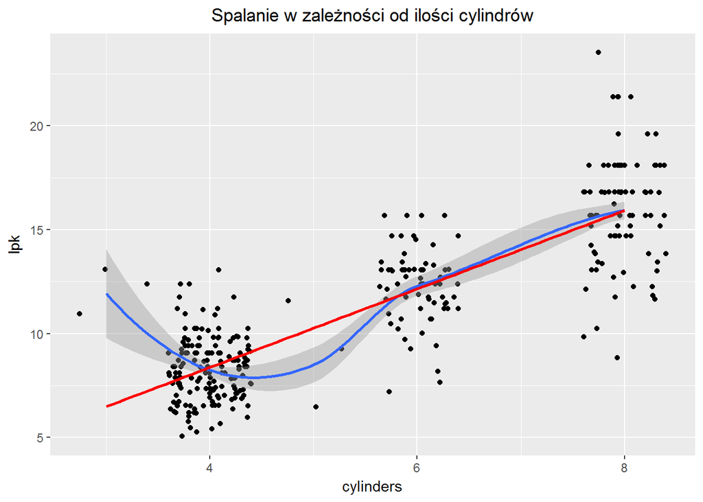

```r
cars %>%
  ggplot(aes(x = cars$cylinders, y = cars$lpk)) +
  geom_jitter() +
  geom_smooth(se = T) +
  geom_smooth(method = "lm", col = "red", se = F) +
  labs(title="Spalanie w zależności od ilości cylindrów", x="cylinders", y="lpk") +
  theme(plot.title = element_text(hjust = 0.5))
```

Współczynnik korelacji:

```
## [1] 0.8439455
```

Zgodnie z założeniem, wraz ze wzrostem liczby cylindrów rośnie ilość spalonego paliwa. Zmienna **cylinders** jest silnie skorelowana ze zmienną **lpk**.

#### Hipoteza 2.

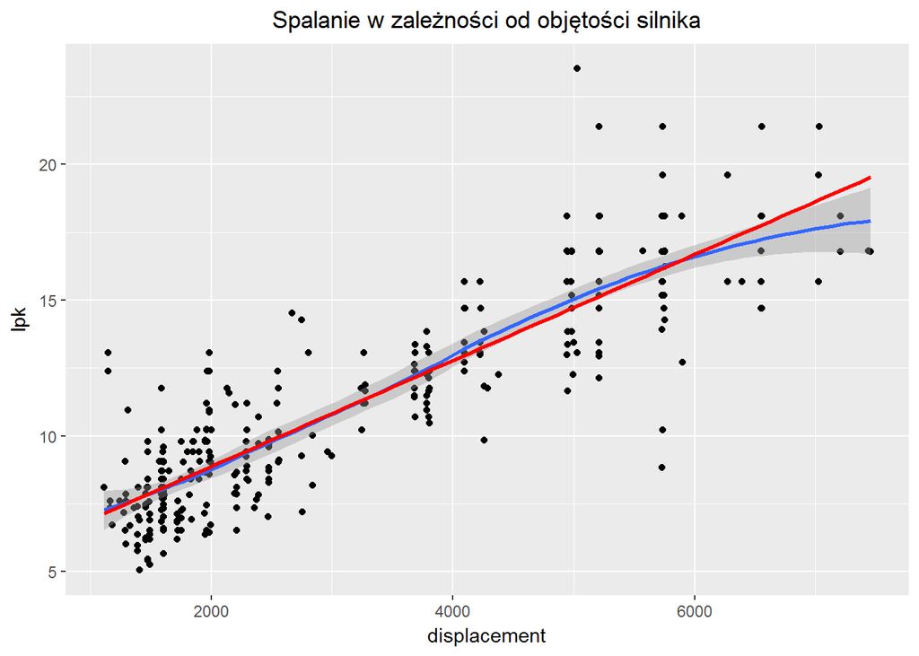

Współczynnik korelacji:

```
## [1] 0.8779143
```

Zgodnie z założeniem, wraz ze wzrostem objętości silnika rośnie ilość spalonego paliwa. Zmienna **displacement** jest silnie skorelowana ze zmienną **lpk**.

#### Hipoteza 3.

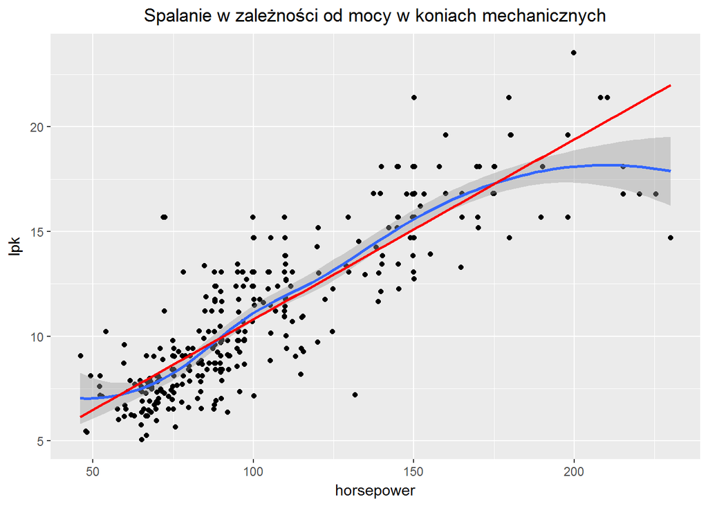

Współczynnik korelacji:

```
## [1] 0.8531513
```

Zgodnie z założeniem, wraz ze wzrostem mocy silnika rośnie ilość spalonego paliwa. Zmienna **horsepower** jest silnie skorelowana ze zmienną **lpk**.

#### Hipoteza 4.

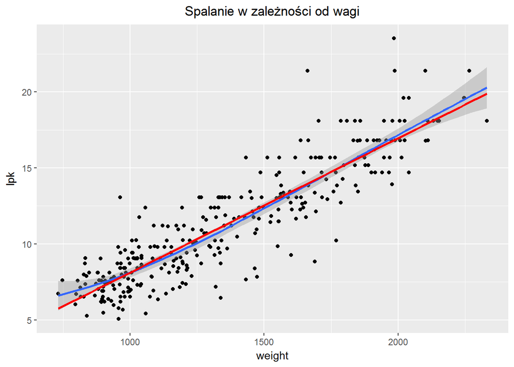

Współczynnik korelacji:

```
## [1] 0.8967855
```

Zgodnie z założeniem, wraz ze wzrostem wagi samochodu rośnie ilość spalonego paliwa. Zmienna **weight** jest silnie skorelowana ze zmienną **lpk**.

#### Hipoteza 5.

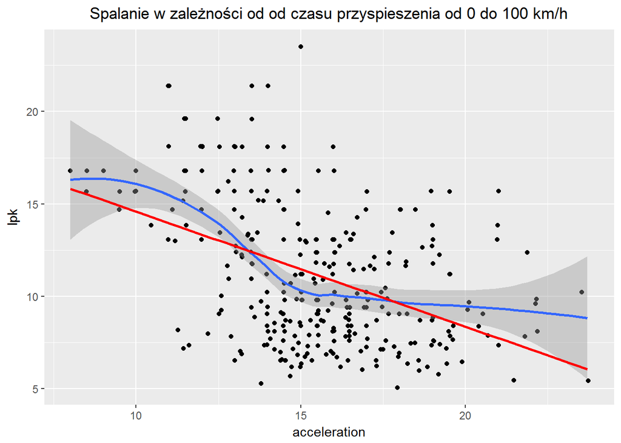

Współczynnik korelacji:

```
## [1] -0.4449116
```

Zgodnie z założeniem, wraz ze wzrostem czasu przyspieszenia od 0 do 100 km/h maleje ilość spalonego paliwa. Zmienna **acceleration** nie jest silnie skorelowana ze zmienną **lpk**.

#### Hipoteza 6.

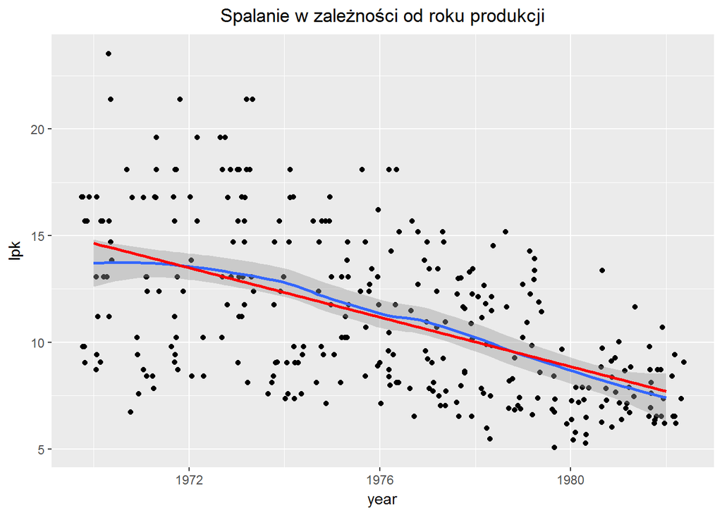

Współczynnik korelacji:

```
## [1] -0.5477062
```

Zgodnie z założeniem, wraz ze wzrostem roku produkcji maleje ilość spalonego paliwa. Zmienna **year** nie jest silnie skorelowana ze zmienną **lpk**.

#### Hipoteza 7.

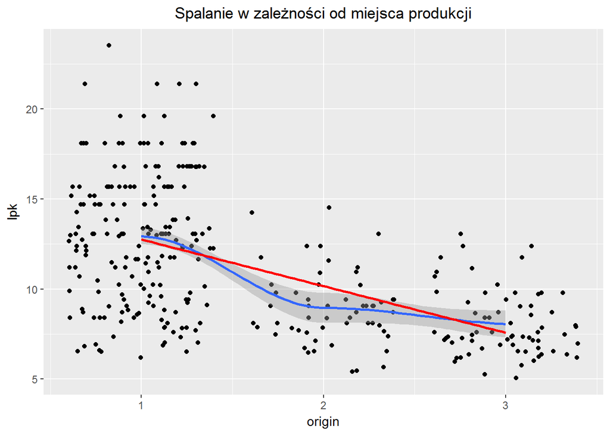

Współczynnik korelacji:

```
## [1] -0.556034
```

Zgodnie z założeniem, średnio najbardziej ekologiczne pojazdy produkowane są w Japonii. Jest to jednak zmienna jakościowa i żeby móc ją wykorzystać musi być najpierw rozbita na zmienne zero-jedynkowe. Oprócz tego zmienna **origin** nie jest silnie skorelowana ze zmienną **lpk**.

#### Hipoteza 8.

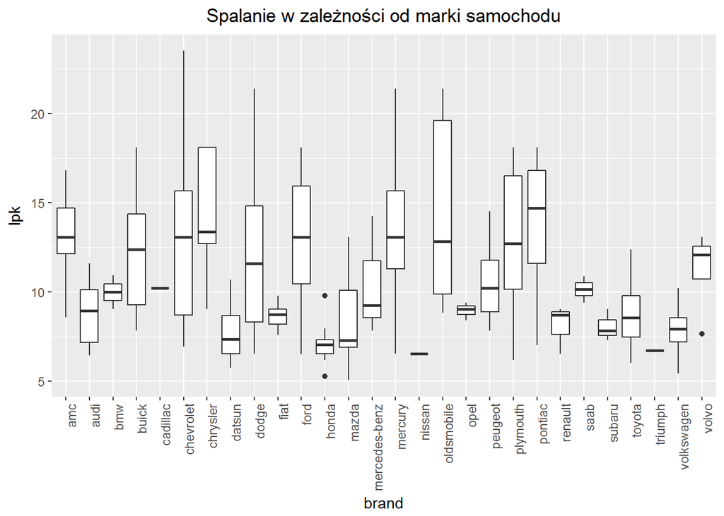

W zestawieniu występują mało liczne obserwacje, zaburzające analizę. Zmniejszę liczbę marek o połowę, uwzględniając tylko te najbardziej liczne.

```r
filtered_brands <- cars %>%
  group_by(brand) %>%
  summarise(amount = n()) %>%
  top_n(floor(28/2)) %>%
  arrange(desc(amount)) %>%
  ungroup() %>%
  inner_join(cars)
```

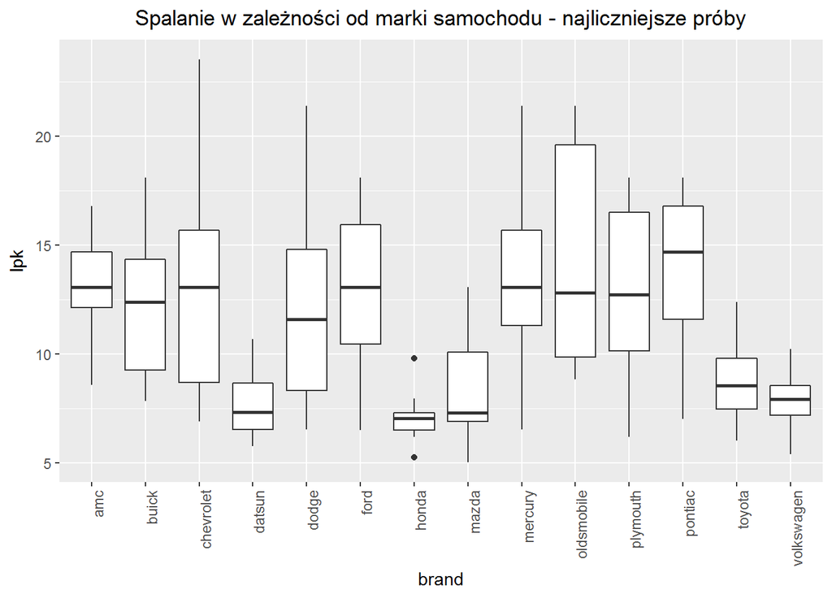

Wykres pudełkowy pokazuje, że zgodnie z przewidywaniami, marki samochodów produkowanych w Japonii (Datsun, Honda, Mazda, Toyota) stawiają na energooszczędność. Japońskie samochody spalają średnio znacznie mniej niż amerykańskie. Marka samochodu może mieć istotny wpływ na spalanie.

Wspołczynnik korelacji:

```
## [1] -0.2182327
```

Dokładam dodatkową kolumnę o nazwie **brandID**, reprezentującą daną markę w postaci liczbowej. Jest to jednak zmienna jakościowa i żeby móc ją wykorzystać musi być najpierw rozbita na zmienne zero-jedynkowe. Oprócz tego zmienna **brand** jest bardzo słabo skorelowana ze zmienną **lpk**.

Podsumowanie korelacji ze zmienną **lpk**:

```
##                     lpk
## cylinders     0.8439455
## displacement  0.8779143
## horsepower    0.8531513
## weight        0.8967855
## acceleration -0.4449116
## year         -0.5477062
## origin       -0.5560340
## brandID      -0.2182327
```

#### Macierz korelacji między zmiennymi objaśniającymi

Decyduję się na pominięcie zmiennych **origin** i **brand** ze względu na ich jakościowy charakter. Mecierz korelacji dla pozostałych zmiennych prezetować się będzie następująco:

[figure not shown]

# Budowa modelu liniowego

W poprzednim rozdziale zaobserwowałam, ze zmiennymi silnie skorelowanymi ze zmienną objaśnianą są: **cylinders**, **displacement**, **horsepower** oraz **weight**. Jednocześnie są one silnie skorelowane między sobą, co stanowi na ich niekorzyść. Natomiast zmiennymi najsłabiej skorelowanymi ze mienną **lpk** i między sobą są: **acceleration** i **year**. Spróbuję dopasować najlepszy model opisujący ilość spalanego paliwa wykorzystując metodę Hellwiga oraz metodę bootstrapową.

### I.Metoda Hellwiga

#### 1. Teoria

Jest to formalna metoda doboru zmiennych objaśniających do modelu statystycznego. Zmienne, które wybieramy do modelu powinny być **silnie skorelowane ze zmienną objaśnianą**, a **słabo skorelowane między sobą**. Nie jest to jednak ścisłe kryterium doboru zmiennych, oprócz tego występuje **kryterium liczbowe**, tzw. *pojemność integralna kombinacji nośników informacji*. W tym przypadku nośnikami informacji są wszystkie zmienne objaśniające.

Zgodnie z teorią jeżeli mamy *m* potencjalnych zmiennych objaśniających, to liczba wszystkich kombinacji jest równa *2<sup>m</sup> - 1*. Dla wszystkich otrzymanych kombinacji definiuję tzw. *Indywidualną pojemność nośników informacji*. Dopiero, gdy policzymy indywidualną pojemność nośników informacji dla wszystkich kombinacji, możemy obliczyć *pojemność integralną kombinacji nośników informacji*, która jest sumą indywidualnych pojemności nośników informacji, wchodzących w skład tej kombinacji. Jest ona kryterium wyboru odpowiedniej kombinacji zmiennych objaśniających, a wybieramy tę kombinację, gdzie wartość **Hk** jest największa.

#### 2. Wyznaczenie zmiennych

Przygotowuje funkcję o nazwie **hellwig**, która zwracać będzie dwie kolumny; pierwszą zawierającą wszystkie kombinacje zmiennych niezależnych i drugą zawierającą *pojemność integralną* dla każdej z tych kombinacji:

```r
hellwig <- function(x, y) {
  R <- cor(x, method="pearson") #macierz korelacji zmiennych objaśniających
  R0 <- cor(x, y, method="pearson") #wektor korelacji pomiędzy objaśnianą a objaśniającymi
  #lista kombinacji
  k <- sapply(seq(2, length(x)), function(i)
              utils::combn(length(x), i, simplify=FALSE))
  k <- do.call("c", k)
  #wyznaczanie indywidualnych pojemności informacji
  hfun <- function(v)
  {
    sapply(v, function(i) R0[i]^2 / sum(abs(R[v,i])) )
  }
  #wyznaczanie pojemności integralnych kombinacji
  h <- sapply(k, hfun)
  #zapisanie do ramki danych
  data.frame(k = sapply(k, paste, collapse="-"),
             h = sapply(h, sum),
             stringsAsFactors=FALSE)
}
```

Wyświetlam wyniki działania funkcji **hellwig** dla 6 zmiennych objaśniających:

```
## Observations: 57
## Variables: 2
## $ k <chr> "1-2", "1-3", "1-4", "1-5", "1-6", "2-3", "2-4", "2-5", "2-6...
## $ h <dbl> 0.7601953, 0.7806535, 0.7987141, 0.6127434, 0.7515947, 0.789...
```

Wyszukuję największą wartość **Hk**:

```
##          k         h
## 47 2-3-4-6 0.8700313
```

Po obliczeniach otrzymuję wartość **Hmax** na poziomie **0.8700313** dla kombinacji zmiennych 2-3-4-6, czyli **displacement**, **horsepower**, **weight** i **year**.

#### 3. Model liniowy

Szacuję wstępny model liniowy, z wykorzystaniem wszystkich zmiennych, za pomocą funkcji **lm**:

```
##
## Call:
## lm(formula = lpk ~ ., data = cars[1:7])
##
## Residuals:
##     Min      1Q  Median      3Q     Max
## -3.4520 -0.7435 -0.0533  0.6092  5.9943
##
## Coefficients:
##                Estimate Std. Error t value Pr(>|t|)
## (Intercept)   5.675e+02  4.458e+01  12.730  < 2e-16 ***
## cylinders     1.752e-01  1.381e-01   1.269  0.20542
## displacement -6.005e-05  1.925e-04  -0.312  0.75529
## horsepower    1.625e-02  6.248e-03   2.601  0.00975 **
## weight        6.270e-03  6.653e-04   9.425  < 2e-16 ***
## acceleration  2.999e-02  4.599e-02   0.652  0.51475
## year         -2.873e-01  2.249e-02 -12.772  < 2e-16 ***
## ---
## Signif. codes:  0 '***' 0.001 '**' 0.01 '*' 0.05 '.' 0.1 ' ' 1
##
## Residual standard error: 1.284 on 306 degrees of freedom
## Multiple R-squared:  0.8894, Adjusted R-squared:  0.8872
## F-statistic: 409.9 on 6 and 306 DF,  p-value: < 2.2e-16
```

Szacuję model liniowy zgodny z wynikami metody Hellwiga:

```
##
## Call:
## lm(formula = lpk ~ displacement + horsepower + weight + year,
##     data = cars[1:7])
##
## Residuals:
##     Min      1Q  Median      3Q     Max
## -3.3558 -0.7749 -0.0650  0.6201  6.0877
##
## Coefficients:
##                Estimate Std. Error t value Pr(>|t|)
## (Intercept)   5.715e+02  4.426e+01  12.910  < 2e-16 ***
## displacement  8.077e-05  1.400e-04   0.577  0.56452
## horsepower    1.303e-02  4.537e-03   2.872  0.00436 **
## weight        6.562e-03  5.547e-04  11.831  < 2e-16 ***
## year         -2.888e-01  2.238e-02 -12.906  < 2e-16 ***
## ---
## Signif. codes:  0 '***' 0.001 '**' 0.01 '*' 0.05 '.' 0.1 ' ' 1
##
## Residual standard error: 1.284 on 308 degrees of freedom
## Multiple R-squared:  0.8886, Adjusted R-squared:  0.8872
## F-statistic: 614.3 on 4 and 308 DF,  p-value: < 2.2e-16
```

Zmienna **displacement** nie została odrzucona przez metodę Hellwiga, chociaż nie jest statystycznie istotna. Pozostałe zmienne są istotne i dobrze opisują zjawisko spalania. Wskaźnik R<sup>2</sup> również jest wysoki i wynosi prawie 89%. Potwierdza to w pewnym stopniu poprawność wykonania modelu metodą Hellwiga.  
Współczynniki:

```
##   (Intercept)  displacement    horsepower        weight          year
##  5.714522e+02  8.076930e-05  1.303118e-02  6.562372e-03 -2.888309e-01
```

#### 4. Test normalności rozkładu reszt

```
##
##  Shapiro-Wilk normality test
##
## data:  modelH$residuals
## W = 0.96232, p-value = 3.056e-07
```

```
##
##  Anderson-Darling normality test
##
## data:  modelH$residuals
## A = 2.3754, p-value = 5.056e-06
```

#### 5. Badanie isototności zmiennych objaśniających

```
## Wald test
##
## Model 1: lpk ~ displacement + horsepower + weight + year
## Model 2: lpk ~ 1
##   Res.Df Df      F    Pr(>F)
## 1    308
## 2    312 -4 614.34 < 2.2e-16 ***
## ---
## Signif. codes:  0 '***' 0.001 '**' 0.01 '*' 0.05 '.' 0.1 ' ' 1
```

Z przeprowadzonego testu Walda wynika, że zmienne objaśniające są istotne.

#### 6. Badanie heteroskedastyczności

Heteroskedastyczność to sytuacja, w której przynajmniej jedna zmienna losowa z ciągu różni się od innych wariancją lub jej wariancja jest nieskończona.

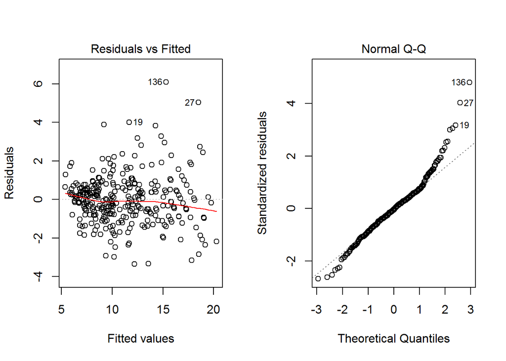

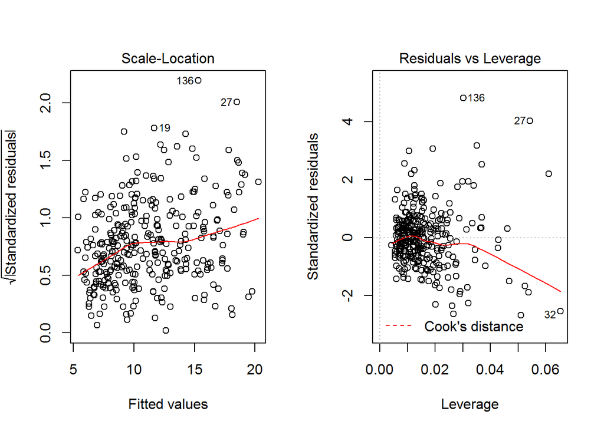

Interesujące nas wykresy znajdują się w lewym górnym - **Residuals vs Fitted** i lewym dolnym rogu - **Scale-Location**. W lewym górnym rogu znajduje się wykres wartości reszt względem dopasowanych wartości, natomiast lewy dolny zawiera standaryzację reszt na osi Y. Jeśli nie występuje heteroskedastyczność, powinniśmy zaobserwować całkowicie losowy, równy rozkład punktów w całym zakresie osi X i płaską czerwoną liniię.  
Z powyższych wykresów można wywnioskować, ze w modelu występuje heteroskedastyczność. Co dodatkowo potwierdze testem **Breusha-Pagana**:

```
##
##  studentized Breusch-Pagan test
##
## data:  modelH
## BP = 23.773, df = 4, p-value = 8.871e-05
```

Wartość p jest bardzo mała co oznacza podstawy do odrzucenia hipotezy zerowej - w modelu występuje heteroskedastyczność.

#### 7. Test Ramsaya RESET

Jets to test poprawności specyfikacji dla modeli regresji liniowej. Stosowany jest w celu sprawdzenia, czy to liniowa postać modelu (względem funkcji kwadratowej, lub sześciennej) jest najlepszym możliwym do wybrania modelem. Test umożliwia sprawdzenie poprawności specyfikacji modelu bez porównywania do alternatywnej postaci, z tego też powodu w przypadku stwierdzenia niepoprawności nie sugeruje on lepszego wariantu.

```r
resettest(modelH, power=2:3, type = "regressor", data=cars[1:7])
```

```
##
##  RESET test
##
## data:  modelH
## RESET = 4.8833, df1 = 8, df2 = 300, p-value = 1.11e-05
```

W wyniku wywołania testu otrzymuję bardzo małą wartość p, bliską zeru. Odrzucam hipotezę zerową na rzecz hipotezy alternatywnej. Oznacza to, że postać modelu nie jest poprawna i występują zmienne pominięte.

### II. Metoda bootstrapowa - nieparametryczna wersja Monte Carlo

#### 1. Teoria

W statystyce bootstrapping to dowolny test lub dane, które polegają na losowym próbkowaniu ze zwracaniem. Bootstrapping pozwala przypisać miary dokładności (zdefiniowane w kategoriach odchylenia, wariancji, przedziałów ufności, błędu prognozowania lub innych podobnych miar) do próbnych oszacowań. Technika ta pozwala na oszacowanie rozkładu próbek prawie każdej statystyki przy użyciu losowych metod próbkowania.

#### 2. Wyznaczenie zmienych

Szacuję model za pomocą bootstrapowej metody krokowej (jedna zmienna – jeden krok) wstecznej z funkcji **boot.stepAIC**, która opiera się na kryterium informacyjnym Akaike’a - **AIC**. Im wartość AIC jest niższa tym lepiej. Ilość symulacji ustawiam na **10000**:

```r
boots <- boot.stepAIC(lm(lpk ~., cars[1:7]), cars[1:7], alpha=.05, direction="backward", B=10000)
```

Po oszacowaniu okazuje się, ze do modelu weszły 3 najistotniejsze zmienne: **horsepower**, **weight** oraz **year**. Współczynnik determinacji modelu jest bardzo wysoki i wynosi prawie 89%, z tą różnicą, że z wykorzystaniem mniejszej ilości zmiennych objaśniających. Zmienna **displacement** sugerowana przez metodę **Hellwiga** została odrzucona już w pierwszym kroku. Oznacza to, że nie jest ona istotna i nie powinna występować w finalnym modelu.

#### 3. Model liniowy

Szacuję model liniowy zgodny z wynikami krokowej metody bootstrapowej:

```
##
## Call:
## lm(formula = lpk ~ horsepower + weight + year, data = cars[1:7])
##
## Residuals:
##     Min      1Q  Median      3Q     Max
## -3.2366 -0.7773 -0.0511  0.6372  6.1285
##
## Coefficients:
##               Estimate Std. Error t value Pr(>|t|)
## (Intercept)  5.741e+02  4.398e+01  13.052  < 2e-16 ***
## horsepower   1.419e-02  4.059e-03   3.497 0.000539 ***
## weight       6.796e-03  3.793e-04  17.917  < 2e-16 ***
## year        -2.902e-01  2.222e-02 -13.062  < 2e-16 ***
## ---
## Signif. codes:  0 '***' 0.001 '**' 0.01 '*' 0.05 '.' 0.1 ' ' 1
##
## Residual standard error: 1.283 on 309 degrees of freedom
## Multiple R-squared:  0.8885, Adjusted R-squared:  0.8874
## F-statistic: 820.8 on 3 and 309 DF,  p-value: < 2.2e-16
```

Wszystkie 3 zmienne uwzględnione w modelu: **horsepower**, **weight** oraz **year** są statystycznie bardzo istotne (***) i dobrze opisują zjawisko spalania. Wskaźnik R<sup>2</sup> jest porównywalnie wysoki do tego uzyskanego metodą Hellwiga i wynosi prawie 89%.

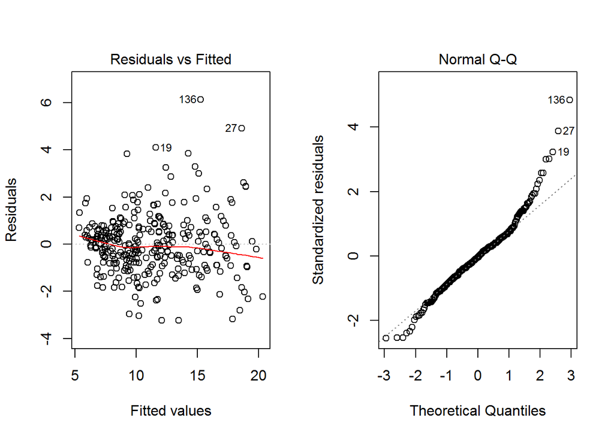

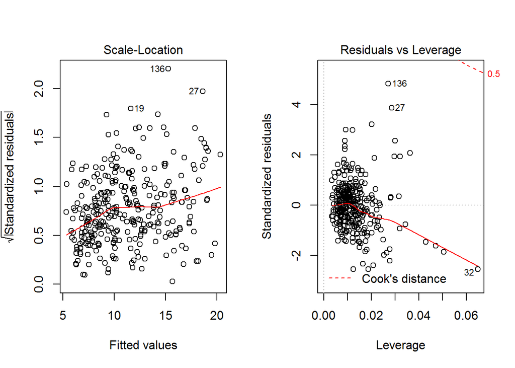

#### 4. Porównanie przedziałów ufności

Zapisuję współczynniki uzyskane dwiema metodami do zmiennych **coefs**, a następnie die ramki danych **hellwigRange** i **bootsRange** wypełniam wartościami przedziałów ufności dla poszczególnych obserwacji.

```r
#zapisanie współczynników z metody Hellwiga
coefsH <- summary(modelH)$coefficients
constRange <- coefsH[1,1] + qnorm(c(.025, .975))*coefsH[1,2]
dispRange <- coefsH[2,1] + qnorm(c(.025, .975))*coefsH[2,2]
horseRange <- coefsH[3,1] + qnorm(c(.025, .975))*coefsH[3,2]
weightRange <- coefsH[4,1] + qnorm(c(.025, .975))*coefsH[4,2]
yearRange <- coefsH[5,1] + qnorm(c(.025, .975))*coefsH[5,2]
hellwigRange <- data.frame("const"=constRange, "displacement"=dispRange, "horsepower"=horseRange, "weight"=weightRange, "year"=yearRange)

#zapisanie współczynników z metody bootstrapowej
coefsB <- summary(modelB)$coefficients
constRange <- coefsB[1,1] + qnorm(c(.025, .975))*coefsB[1,2]
horseRange <- coefsB[2,1] + qnorm(c(.025, .975))*coefsB[2,2]
weightRange <- coefsB[3,1] + qnorm(c(.025, .975))*coefsB[3,2]
yearRange <- coefsB[4,1] + qnorm(c(.025, .975))*coefsB[4,2]
bootsRange <- data.frame("const"=constRange, "horsepower"=horseRange, "weight"=weightRange, "year"=yearRange)
```

```r
hellwigRange
```

```
##      const  displacement horsepower      weight       year
## 1 484.6982 -0.0001936995 0.00413896 0.005475207 -0.3326928
## 2 658.2062  0.0003552381 0.02192340 0.007649537 -0.2449690
```

```r
bootsRange
```

```
##      const  horsepower      weight       year
## 1 487.8527 0.006239338 0.006052230 -0.3337933
## 2 660.2668 0.022150712 0.007538969 -0.2466887
```

Z tabelek można zaobserwować, że przedziały ufności współczynników **horsepower** oraz **weight** uzyskaych metodą bootstrapową, są nieco węższe od tych uzyskanych metodą Hellwiga. Dla zmiennej **year** nie zaobserwowano istotnej różnicy.

#### 5. Wykresy rozkładów współczynników

Dokonam porównania przedziałów ufności współczynników uzyskanych metodą Hellwiga oraz metodą bootstrapową. Wykresy będą prezentowały wartości 3 zmiennych które zostały uwzględnione w dwóch testach. Są to: **horsepower**, **weight**, oraz **year**.

##### 5.1 Współczynnik horsepower

Łączę wyniki dwóch metod we wspólną ramkę danych **par_horsepower**. Dla pozostałych zmiennych postępuję analogicznie.

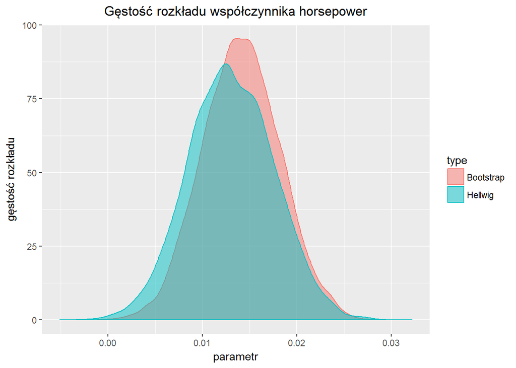

```r
par_horsepower <- tibble(Bootstrap = coefsB[2,1] + rnorm(10^4)*coefsB[2,2],
                         Hellwig = coefsH[3,1] + rnorm(10^4)*coefsH[3,2]) %>% gather(type, parameter)
par_horsepower %>%
  ggplot(aes(x = parameter, col = type, fill= type)) +
  geom_density(alpha = .5) +
  labs(title="Gęstość rozkładu współczynnika horsepower", x="parametr", y="gęstość rozkładu") +
  theme(plot.title = element_text(hjust = 0.5))
```

Przedział ufności współczynnika **horsepower** uzyskany metodą bootstrapową jest nieznacznie węższy od uzyskanego metodą Hellwiga. Może to świadczyć o lepszym dopasownaiu modelu.

##### 5.2 Współczynnik weight

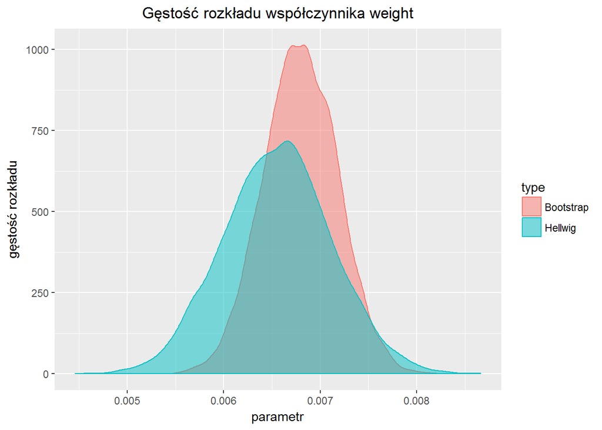

Wykres bootstrapowy jest przesunięty względem uzyskanego metodą Hellwiga. Bootstrapowy przedział ufności dla współczynnika **weight** jest znacznie węższy, co może świadczyć o lepszym dopasowaniu modelu.

##### 5.2 Współczynnik year

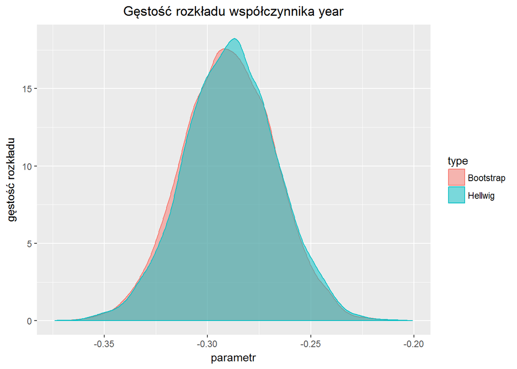

Przedziały ufności uzyskane obiema metodami nie różnią się istotnie.

# Podsumowanie

Model sporządzony z wykorzystaniem metody Hellwiga wydaję się słabszy i mniej dokładne opisujący zjawisko spalania niż model stworzony metodą bootstrapową. Po przenalizowaniu modelu Hellwiga okazuje się, że nie spełnia on podstawowych wymagań, takich jak normalność rozkładu reszt czy brak heteroskedastyczności. Model bootstrapowy nie może być zdiagnozowany pod tym samym kątem co model sporządzony z wykorzystaniem metody klasycznej, ze względu na brak przewidywanych założeń. Jednak po porównaniu przedziałów ufności, okazał się dokładniejszy, a zatem istnieją podstawy by sądzić, że lepiej opisuje on omawiany proces spalania.